# Mini Project 1

Prajwal Bhandari, Cameron Moore

2025-03-06

## Front matter

```r
# import libraries
# remove(list = ls())
library(tidyverse)
library(readxl)
# read data
cod <- read_xlsx("CODGames2_mp.xlsx", sheet = 1)
```

## Preliminary

```r
glimpse(cod)
```

```
## Rows: 211
## Columns: 27
## $ Map1           <chr> "Moscow", "Moscow", NA, "Drive-In", "Collateral Strike"…
## $ Map2           <chr> "Miami Strike", "WMD", NA, "Jungle", "Hijacked", "Raid"…
## $ Choice         <chr> "Miami Strike", "Moscow", "Yamantau", "Drive-In", "Coll…
## $ MapVote        <chr> "5 to 0", "2 to 0", NA, "2 to 0", "3 to 3", "4 to 3", N…
## $ Date           <dttm> 2022-06-06, 2022-06-06, 2022-06-06, 2022-06-06, 2022-0…
## $ FullPartial    <chr> "Full", "Full", "Full", "Full", "Full", "Full", "Full",…
## $ Result         <chr> "100-97", "76-89", "100-92", "80-100", "71-100", "85-10…
## $ Eliminations   <dbl> 22, 20, 18, 10, 11, 7, 10, 18, 4, 11, 23, 10, 11, 17, 1…
## $ Deaths         <dbl> 17, 15, 11, 19, 19, 18, 21, 14, 4, 23, 12, 11, 20, 12, …
## $ Score          <dbl> 4070, 5305, 3335, 2170, 2195, 850, 2240, 3505, 965, 198…
## $ Damage         <dbl> 634, 560, 483, 280, 308, 196, 259, 504, 111, 304, 617, …
## $ TotalXP        <dbl> 11002, 9451, 12948, 11502, 11133, 10077, 8527, 16703, 7…
## $ PrimaryWeapon  <chr> "M16", "M16", "M16", "M16", "M16", "M16", "M16", "M16",…
## $ XPType         <chr> "10% Boost", "10% Boost", "10% Boost", "Double XP + 10%…
## $ DidPlayerVote  <chr> "No", "No", "No", "No", "No", "No", "No", "No", "No", "…
## $ GameType       <chr> "HC - TDM", "HC - TDM", "HC - TDM", "HC - TDM", "HC - T…
## $ Confirms       <dbl> NA, NA, NA, NA, NA, NA, NA, NA, 5, 8, 8, NA, NA, NA, NA…
## $ Denies         <dbl> NA, NA, NA, NA, NA, NA, NA, NA, 1, 4, 9, NA, NA, NA, NA…
## $ Objectives     <dbl> NA, NA, NA, NA, NA, NA, NA, NA, 6, 12, 17, NA, NA, NA, …
## $ ObjectiveKills <dbl> NA, NA, NA, NA, NA, NA, NA, NA, NA, NA, NA, NA, NA, NA,…
## $ Captures       <dbl> NA, NA, NA, NA, NA, NA, NA, NA, NA, NA, NA, NA, NA, NA,…
## $ Diffuses       <lgl> NA, NA, NA, NA, NA, NA, NA, NA, NA, NA, NA, NA, NA, NA,…
## $ Plants         <lgl> NA, NA, NA, NA, NA, NA, NA, NA, NA, NA, NA, NA, NA, NA,…
## $ Detonates      <lgl> NA, NA, NA, NA, NA, NA, NA, NA, NA, NA, NA, NA, NA, NA,…
## $ Deposits       <lgl> NA, NA, NA, NA, NA, NA, NA, NA, NA, NA, NA, NA, NA, NA,…
## $ Time_Sec       <dbl> NA, NA, NA, NA, NA, NA, NA, NA, NA, NA, NA, NA, NA, NA,…
## $ Time_Min       <dbl> NA, NA, NA, NA, NA, NA, NA, NA, NA, NA, NA, NA, NA, NA,…
```

In this data, there are 211 observations, each with 27 different attributes. Variables like `map1`, `map2`, `PrimaryWeapom`, and other character variables could be converted into factors for easier analysis. The variable `XPType` could be converted to a numerical value instead of staying as a character variable. We could do some easy math to arrive at an XP multiplier that is applied to each game. Finally, variables like the date could be parsed by functions from the lubridate package that would make working with them easier. Other work like changing all the NA values in `ObjejctiveKills`, `Captures`, `Plants`, and others would make more sense to make the analysis easier and so that we don’t have to work with missing data. If there are columns with too many NA values, we could also drop them since they would not be helpful to us.

We can make the following changes and then begin variable exploration.

```r
cod_working <- cod %>%
  rename(
    map1 = Map1,
    map2 = Map2,
    choice = Choice,
    map_vote = MapVote,
    date = Date,
    full_partial = FullPartial,
    result = Result,
    eliminations = Eliminations,
    deaths = Deaths,
    score = Score,
    damage = Damage,
    total_xp = TotalXP,
    primary_weapon = PrimaryWeapon,
    xp_multiplier = XPType, # call this multiplier, will convert in next command
    did_player_vote = DidPlayerVote,
    game_type = GameType,
    confirms = Confirms,
    denies = Denies,
    objectives = Objectives,
    objective_kills = ObjectiveKills,
    captures = Captures,
    diffuses = Diffuses,
    plants = Plants,
    detonates = Detonates,
    deposits = Deposits,
    time_sec = Time_Sec,
    time_min = Time_Min
  ) %>%
  mutate(  # for now, only mutating variables we think are important
    map1 = as.factor(map1),
    map2 = as.factor(map2),
    choice = as.factor(choice),
    full_partial = as.factor(full_partial),
    primary_weapon = as.factor(primary_weapon),
    xp_multiplier = if_else(xp_multiplier == '10% Boost', 1.10, 2.10),
    did_player_vote = as.logical(if_else(did_player_vote == 'Yes',1,0)),
  ) %>%
  separate(result, into = c('team_result', 'other_team_result'), sep = '-', extra = 'merge', convert = TRUE)

# drop columns with a lot of NA values, so count the values first
apply(cod_working, MARGIN = 2, FUN = function(x) sum(is.na(x))) # counts total NA in columns
```

```
##              map1              map2            choice          map_vote
##                43                43                 1                43
##              date      full_partial       team_result other_team_result
##                 0                 0                 0                 0
##      eliminations            deaths             score            damage
##                 0                 0                 0                 0
##          total_xp    primary_weapon     xp_multiplier   did_player_vote
##                 0                 0                 0                 0
##         game_type          confirms            denies        objectives
##                 0               208               208               205
##   objective_kills          captures          diffuses            plants
##               200               208               211               211
##         detonates          deposits          time_sec          time_min
##               211               211               203               203
```

```r
# since NA values are either < 50 or >200 drop all columns with more than 200 NA values

cod_working <- cod_working %>%
  select(where(~ sum(is.na(.)) < 200))
```

## Variable Exploration

The first variable we decided to explore is `choice`. It is a categorical variable and there is only one missing value for this variable.

```r
sum(is.na(cod_working$choice))
```

```
## [1] 1
```

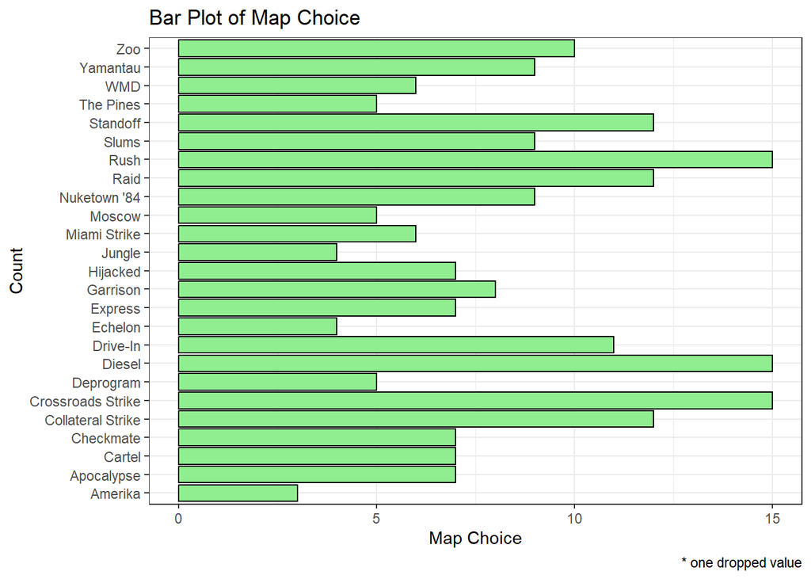

```r
data.frame(cod_working$choice) %>% # convert sngle col into dataframe
  na.omit() %>% # makes sense to omit single observation in one variable
  ggplot(aes(x = cod_working.choice)) +
  geom_bar(fill = 'lightgreen', color = 'black') +
  coord_flip() +
  labs(
    y = 'Map Choice',
    x = 'Count',
    title = 'Bar Plot of Map Choice',
    caption = '* one dropped value'
  ) +
  theme_bw()
```

From the bar chart above, there are a few observations that we can make. The least chosen map is ‘Amerika’ with 3 picks, the the most chosen are ‘Rush’, ‘Diesel’, and ‘Crossroads Strike’ with 15 picks. Other maps tend to be between 5 and 12 picks. It’s interesting to see that the maps are not chosen equally. Further questions could be asked about why some maps are chosen more than others but that is outside the scope of our analysis.

The second variable that we thought is interesting to explore is ‘eliminations’. It is a quantitative variable and there are no missing values. This variable represents the amount of kills per round so it can take any non-negative integer value.

```r
sum(is.na(cod_working$eliminations))
```

```
## [1] 0
```

```r
cod_working %>%
  dplyr::select(eliminations) %>%
  summarize(min = min(eliminations),
            max = max(eliminations),
            mean = mean(eliminations),
            median = median(eliminations),
            sd = sd(eliminations))
```

```
## # A tibble: 1 × 5
##     min   max  mean median    sd
##   <dbl> <dbl> <dbl>  <dbl> <dbl>
## 1     2    39  15.1     14  6.13
```

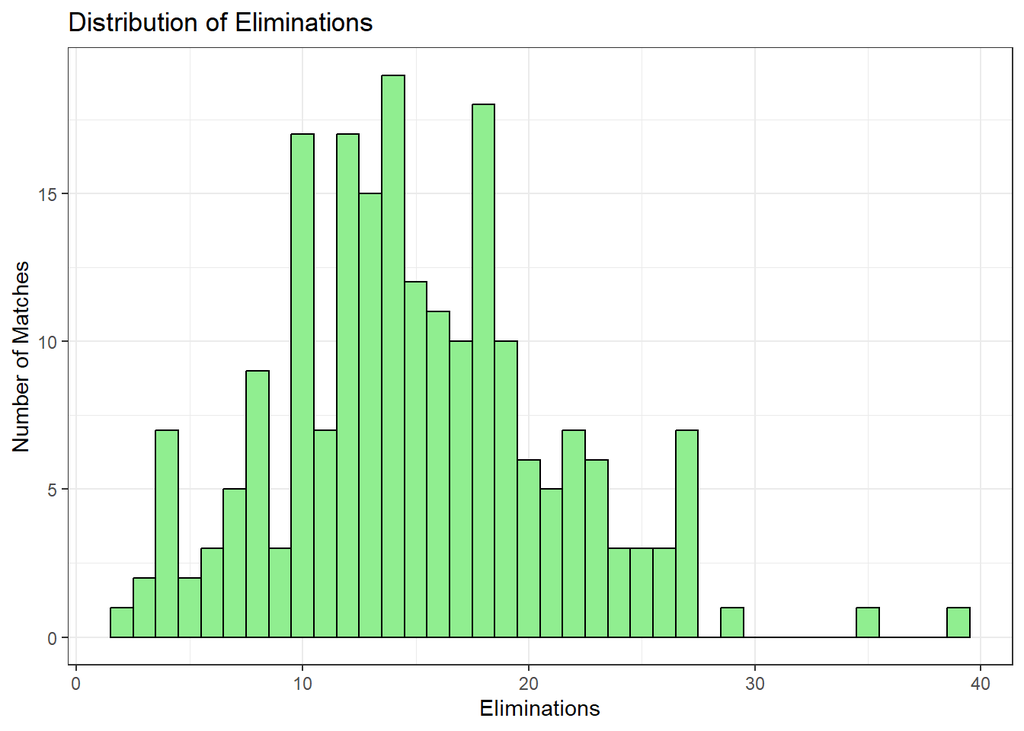

```r
data.frame(cod_working$eliminations) %>%
  ggplot(aes(x = cod_working$eliminations)) +
    geom_histogram(binwidth = 1, fill = 'lightgreen', color = 'black') +
    labs(title = "Distribution of Eliminations",
      x = "Eliminations",
      y = "Number of Matches"
    ) +
  theme_bw()
```

From the histogram and summary statistics above, there are a few observations we can make. The eliminations ranged from 2 to 39, with many values falling in between 10 and 20. The distribution is right skewed with a mean of 15.09005 and a median of 14. The histogram shows that there were a few good matches where players had over 30 eliminations, and some poor matches with under 10 eliminations. However, most fell in between 10 and 20 as I said before.

The third variable that we thought is interesting to explore is the `primary_weapon` variable, which is self explanatory. There are 9 different primary weapons that are used: M16, MP5, AK47, Krig 6, QBZ-83, Pelington 703 FFAR 1, Type 63, and the MG82. Like we saw above, there are no missing values in this variable.

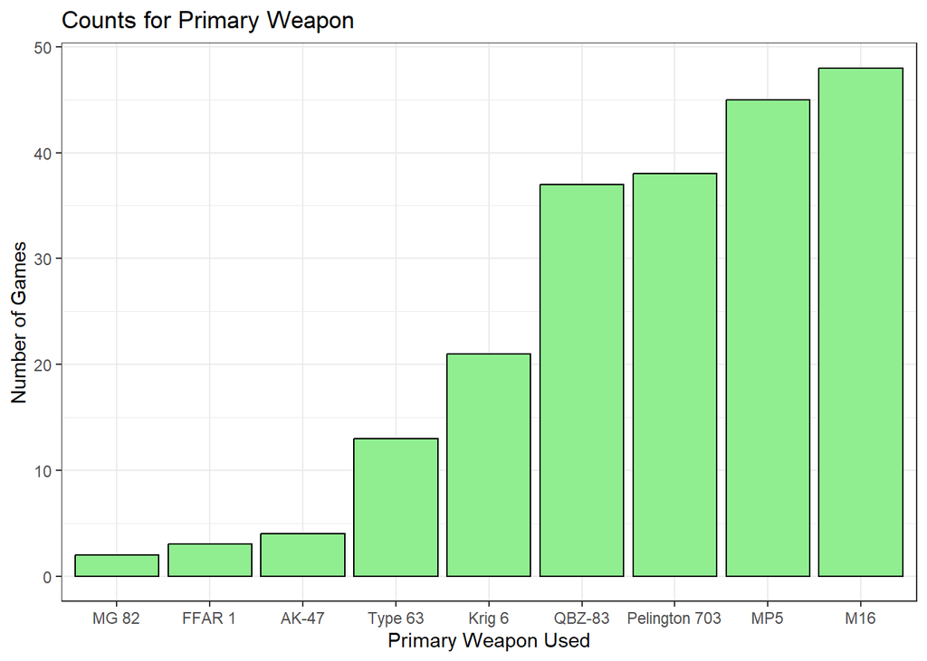

```r
ggplot(data = cod_working, mapping = aes(x = fct_reorder(primary_weapon,primary_weapon, .fun = length))) +
  geom_bar(fill = 'lightgreen', color = 'black') +
  labs(
    x = 'Primary Weapon Used',
    y = 'Number of Games',
    title = 'Counts for Primary Weapon'
  ) +
  theme_bw()
```

It’s interesting to see the disparity between weapon choice. The M16 was used in 48 games, while weapons like the MG 82, FFAR 1 and AK-47 were used in less than 5 games. Some potential reasons would be that the player has a favorite weapon, although that is also outside the scope of this analysis.

We then analyze the `score` variable. It’s quantitative, can take any integer larger than 0, and has no missing values.

```r
cod_working %>%
  select(score) %>%
  summarize(min = min(score),
            max = max(score),
            mean = mean(score),
            median = median(score),
            std = sd(score)
            )
```

```
## # A tibble: 1 × 5
##     min   max  mean median   std
##   <dbl> <dbl> <dbl>  <dbl> <dbl>
## 1   100  7315 2945.   2770 1465.
```

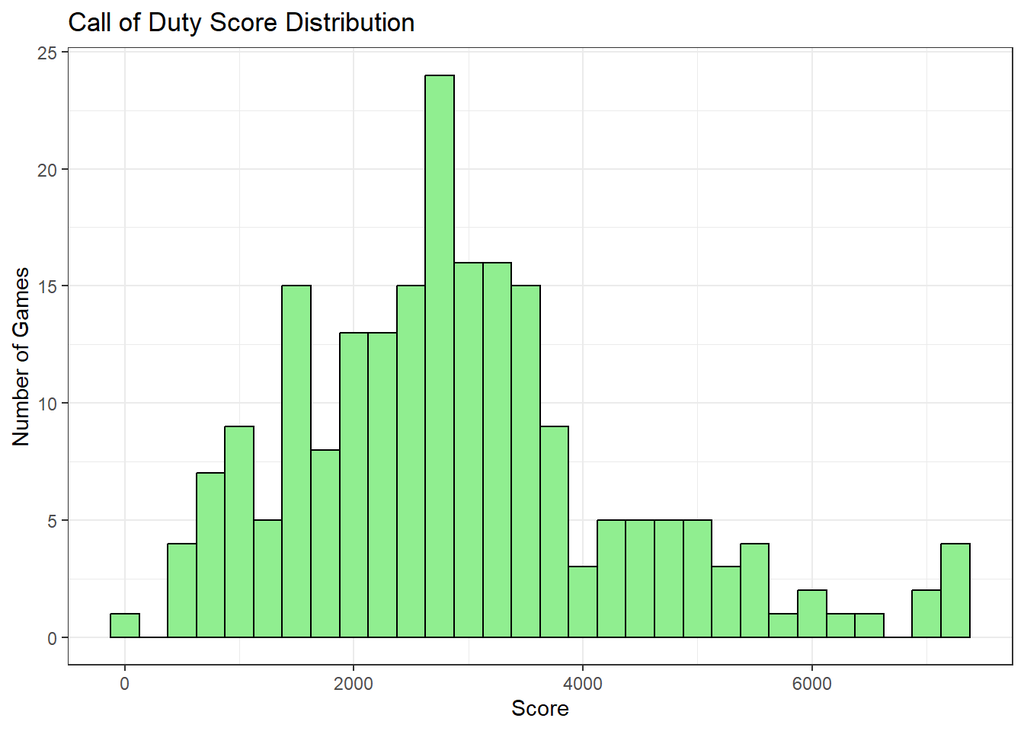

```r
ggplot(data = cod_working, mapping = aes(x = score)) +
  geom_histogram(binwidth = 250, fill = 'lightgreen', color = 'black') +
  labs(
    x = 'Score',
    y = 'Number of Games',
    title = 'Call of Duty Score Distribution') +
  theme_bw()
```

We see that the scores range from 100 to 7300. It takes a mean of 2944 with a standard deviation of 1464. We see that the mean is slightly higher than the median (around 200), which indicates a little right skew. This is also confirmed by the histogram, where there are a few outliers that are much higher than the bulk of the data.

The fifth variable that we thought is interesting to explore is ‘damage’. It is a quantitative variable and there are no missing values. This variable represents the amount of damage a player does in total per round.

```r
sum(is.na(cod_working$damage))
```

```
## [1] 0
```

```r
cod_working %>%
  dplyr::select(damage) %>%
  summarize(min = min(damage),
            max = max(damage),
            mean = mean(damage),
            median = median(damage),
            sd = sd(damage))
```

```
## # A tibble: 1 × 5
##     min   max  mean median    sd
##   <dbl> <dbl> <dbl>  <dbl> <dbl>
## 1    56   960  415.    397  166.
```

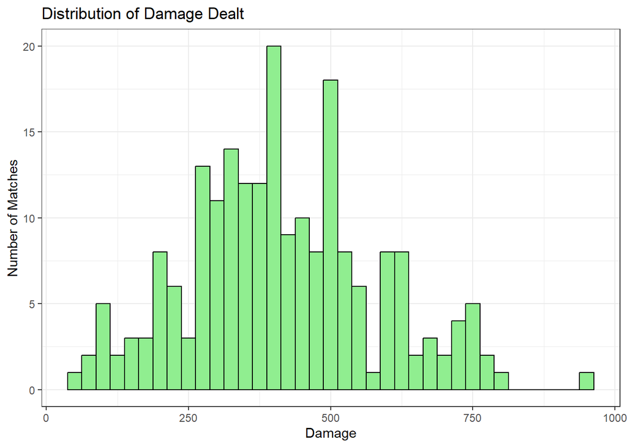

```r
data.frame(cod_working$damage) %>%
  ggplot(aes(x = cod_working$damage)) +
    geom_histogram(binwidth = 25, fill = 'lightgreen', color = 'black') +
    labs(title = "Distribution of Damage Dealt",
      x = "Damage",
      y = "Number of Matches"
    ) +
  theme_bw()
```

From the histogram and summary statistics above, there are a few observations we can make. The damage ranged from 56 to 960, with many values falling in between 250 and 550. The distribution is pretty evenly skewed with a mean of 415.1659 and a median of 397. The histogram shows that there were a few good matches where players had over 750 damage, and some poor matches with under 200 damage. However, most fell in between 250 and 550 as mentioned before.

## Questions about the data

- Was there a single person playing all these matches or multiple(how many)?
- Are all the matches the same length of time?
- How is totalxp calculated?

## Answering Questions with Data Visualizations

- Question: Is the player’s performance, as quantified by the experience points gained (TotalXP variable) changing over time?

To answer this question, we should use the lubridate package to extract the dates into something we can work with and then formatting them to only include the month of the year. Then we can change the month into a categorical variable for easier analysis. By inspecting the data, we see that only games played June, July, and August are recorded, so we could make something like a boxplot or violin plot to visualize the distribution of scores.

```r
cod_working$date <- format(as.Date(cod_working$date),"%B")  # extract month
cod_working$date <- as.factor(cod_working$date)  # make categorical
```

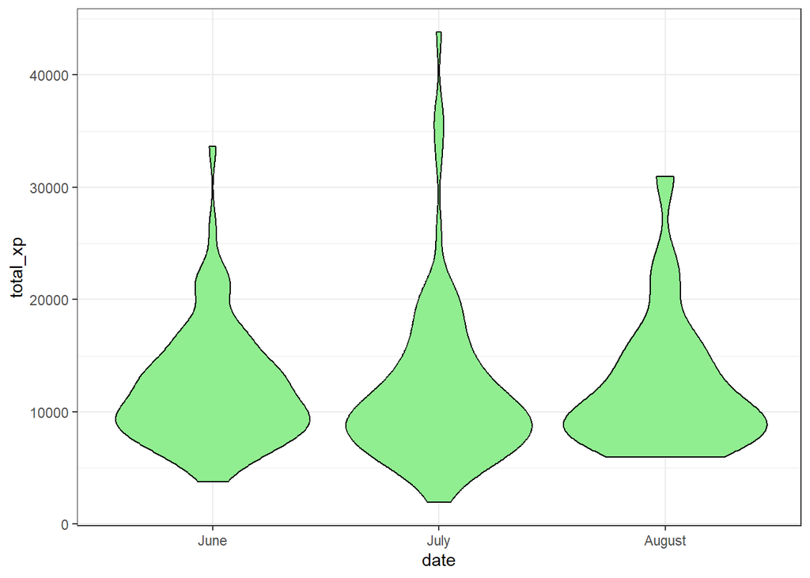

```r
cod_working <- cod_working %>%
  mutate(
    date = fct_relevel(date, 'June', 'July', 'August') # change order to be chronological
  )

ggplot(data = cod_working, mapping = aes(x = date, y = total_xp)) +
  geom_violin(fill = 'lightgreen', color = 'black') +
  theme_bw()
```

From the violin plot, we can see some interesting results about the total xp distribution. All three months had similar centers, but different spreads of the data. It looks like from June to August, the spread of the data got more concentrated, which we can see from the wider tails near the top of the distribution (and also a lower spread in the violin). July, however, was much different as the distribution was much wider in values. That month, we saw both the highest and lowest score in the games. Across all three months, the most common value was around 10,000 XP points, which is where we see the bulk of the distribution.

- Our question: How is the kill death ratio or KD (eliminations over deaths) correlated with score?

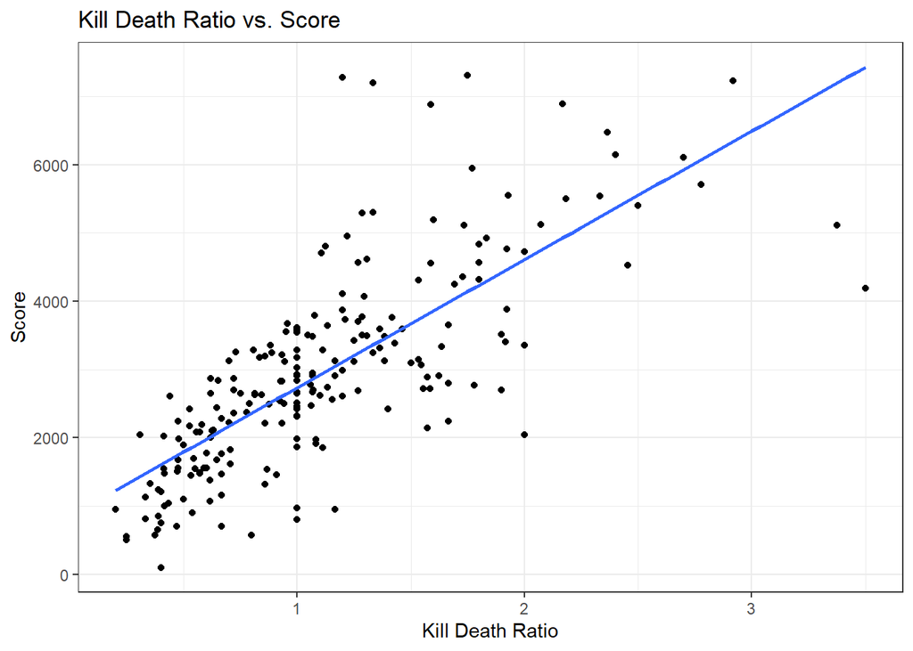

```r
cod_working_question <- data.frame(
  eliminations = cod_working$eliminations,
  deaths = cod_working$deaths,
  score = cod_working$score
)

cod_working_question <- cod_working_question %>%
  mutate(kd = eliminations / deaths)

ggplot(data = cod_working_question, mapping = aes(x = kd,
                     y = score)) +
  geom_point() +
  geom_smooth(method = 'lm', se = FALSE) +
  labs(title = "Kill Death Ratio vs. Score",
         x = "Kill Death Ratio",
         y = "Score") +
  theme_bw()
```

```r
summary(lm(score ~ kd, data = cod_working_question))
```

```
##
## Call:
## lm(formula = score ~ kd, data = cod_working_question)
##
## Residuals:
##     Min      1Q  Median      3Q     Max
## -3248.1  -558.4   -13.2   521.6  4169.8
##
## Coefficients:
##             Estimate Std. Error t value Pr(>|t|)
## (Intercept)    854.7      144.2   5.927 1.26e-08 ***
## kd            1879.6      114.9  16.363  < 2e-16 ***
## ---
## Signif. codes:  0 '***' 0.001 '**' 0.01 '*' 0.05 '.' 0.1 ' ' 1
##
## Residual standard error: 972.3 on 209 degrees of freedom
## Multiple R-squared:  0.5616, Adjusted R-squared:  0.5595
## F-statistic: 267.8 on 1 and 209 DF,  p-value: < 2.2e-16
```

The OLS Model for score on KD is
$$\hat{Score} = 854.7+1879.6KD$$
For every increase in KD, we can expect the score to increase by almost 1900 points.

## Discussion on Group Contributions.

Cameron and I worked quite well on this project and split the work evenly. I did the preliminary data cleaning and analysis of three of the 5 variables. I also was responsible for part 1 of part 4. Cameron did the other two variables and did part 2 of part 4. We worked well to maintain a consistent format in the project with the graphs and story telling (coordinating plot themes and colors).